# Analysing Election Tweets

Deepak Kumar G S

November 19, 2017

# Introduction

In this mini project,I intend to know about the tweet distribution of the two candidates for the presidential election 2016.I will be using wordcloud,TF-IDF,tokenisation procedures to mine and understand the scenario.

I have used [this](http://tidytextmining.com/twitter.html) link for reference.

# Loading libraries,dataset

```r
library(lubridate)
library(ggplot2)
library(dplyr)
library(tidytext)
library(tm)
library(wordcloud)
library(readr)
library(tidyr)
library(RColorBrewer)
library(stringr)
library(RSentiment)
library(cowplot)
library(ggthemes)
library(knitr)
library(kableExtra)
tweets=read.csv("tweets.csv",header=TRUE,stringsAsFactors = FALSE)
summary(tweets)
```

```
##        id               handle              text
##  Min.   :6.842e+17   Length:6444        Length:6444
##  1st Qu.:7.226e+17   Class :character   Class :character
##  Median :7.464e+17   Mode  :character   Mode  :character
##  Mean   :7.414e+17
##  3rd Qu.:7.617e+17
##  Max.   :7.809e+17
##
##   is_retweet        original_author        time
##  Length:6444        Length:6444        Length:6444
##  Class :character   Class :character   Class :character
##  Mode  :character   Mode  :character   Mode  :character
##
##
##
##
##  in_reply_to_screen_name in_reply_to_status_id in_reply_to_user_id
##  Length:6444             Min.   :7.218e+17     Min.   :2.177e+07
##  Class :character        1st Qu.:7.635e+17     1st Qu.:1.340e+09
##  Mode  :character        Median :7.755e+17     Median :1.340e+09
##                          Mean   :7.655e+17     Mean   :1.282e+09
##                          3rd Qu.:7.768e+17     3rd Qu.:1.340e+09
##                          Max.   :7.808e+17     Max.   :1.537e+09
##                          NA's   :6242          NA's   :6236
##  is_quote_status        lang           retweet_count    favorite_count
##  Length:6444        Length:6444        Min.   :   123   Min.   :   274
##  Class :character   Class :character   1st Qu.:  1458   1st Qu.:  3866
##  Mode  :character   Mode  :character   Median :  2825   Median :  7696
##                                        Mean   :  4396   Mean   : 11651
##                                        3rd Qu.:  5404   3rd Qu.: 15118
##                                        Max.   :490180   Max.   :660384
##
##    longitude          latitude       place_id         place_full_name
##  Min.   :-118.41   Min.   :33.45   Length:6444        Length:6444
##  1st Qu.: -90.33   1st Qu.:39.30   Class :character   Class :character
##  Median : -74.70   Median :40.71   Mode  :character   Mode  :character
##  Mean   : -85.29   Mean   :39.31
##  3rd Qu.: -73.89   3rd Qu.:40.77
##  Max.   : -73.88   Max.   :41.99
##  NA's   :6432      NA's   :6432
```

[output cut: 17 more lines]

```
##  Length:6444        Length:6444        Length:6444
##  Class :character   Class :character   Class :character
##  Mode  :character   Mode  :character   Mode  :character
##
##
##
##
##    entities         extended_entities
##  Length:6444        Length:6444
##  Class :character   Class :character
##  Mode  :character   Mode  :character
##
##
##
##
```

# Distribution of Tweets

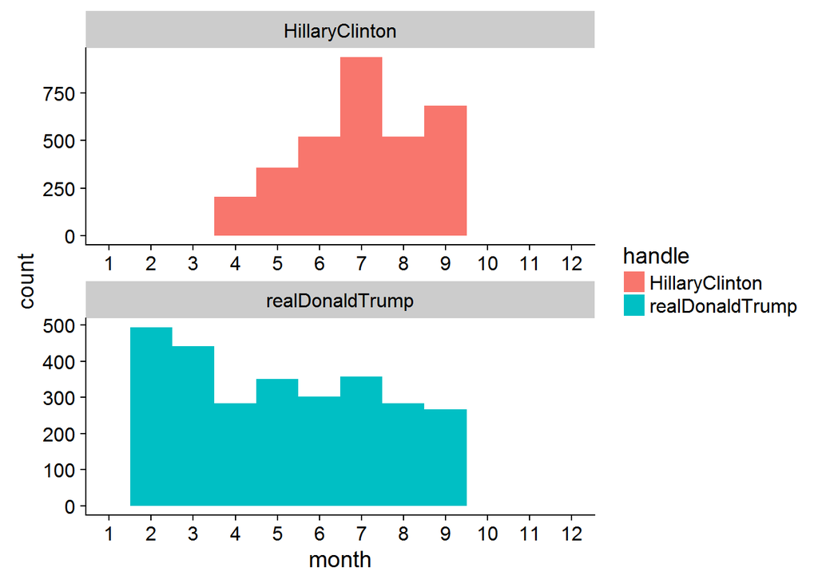

```r
tweets$time=ymd_hms(tweets$time)
tweets$year=as.numeric(year(tweets$time))
tweets$month=as.numeric(month(tweets$time))
tweets$clock=as.numeric(hour(tweets$time))
ggplot(tweets,aes(month,fill=handle))+geom_histogram(binwidth=1,aes(y=..count..))+facet_wrap(~handle,ncol=1,scales="free")+scale_x_continuous(limits=c(1,12),breaks=seq(1,12,1))
```

From the histogram,the tweet distribution for Hillary seems to be high during the month of July whereas for Trump more tweets have been published in the month of Jan-Feb.

# What time of the day does the tweets appear to peak?

We remove the retweeted text and analyse.

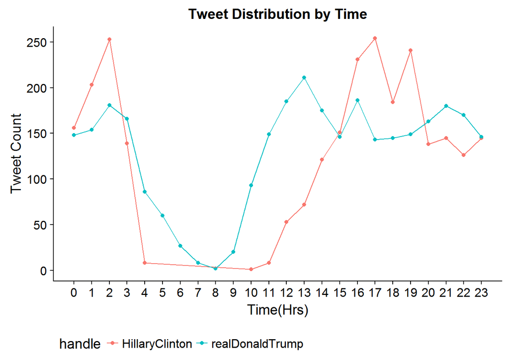

```r
temp=tweets  %>%  filter(!(is_retweet=="True")) %>% select(handle,clock)
temp=temp %>% group_by(handle,clock) %>% tally()
ggplot(temp,aes(clock,n,fill=handle,color=handle))+geom_point()+geom_line()+theme(legend.position="bottom",plot.title=element_text(hjust=0.5))+labs(x="Time(Hrs)",y="Tweet Count",title="Tweet Distribution by Time")+scale_x_continuous(limits=c(0,23),breaks=seq(0,23,1))
```

# Tweet Distribution by Month

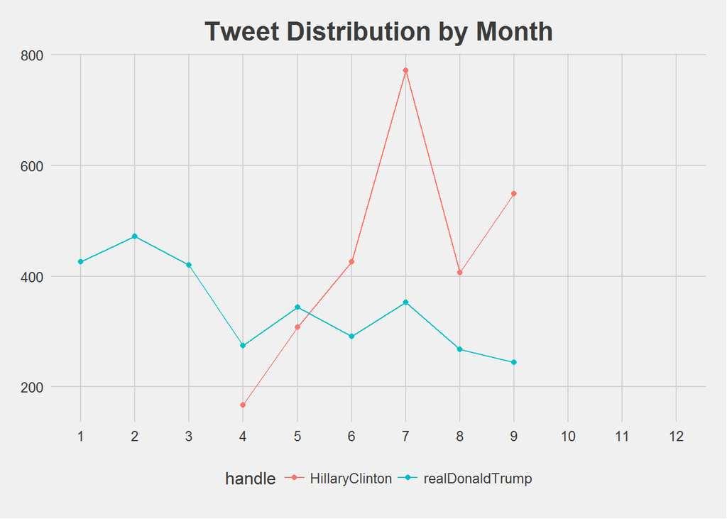

```r
temp=tweets %>% filter(!(is_retweet=="True")) %>% select(handle,month)
temp=temp %>% group_by(handle,month) %>% tally()
ggplot(temp,aes(month,n,fill=handle,color=handle))+geom_point()+geom_line()+theme_fivethirtyeight()+theme(legend.position="bottom",plot.title=element_text(hjust=0.5))+labs(x="Month",y="Tweet Count",title="Tweet Distribution by Month")+scale_x_continuous(limits=c(1,12),breaks=seq(1,12,1))
```

# Word Length:

We examine the median word length distribution of the tweets by a barplot

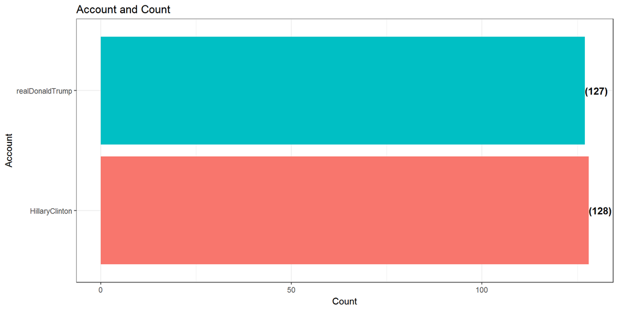

```r
tweets$len=str_count(tweets$text)
temp=tweets %>% group_by(handle) %>% summarise(mediancount=median(len,na.rm=TRUE)) %>% ungroup() %>% mutate(account=reorder(handle,mediancount))
ggplot(temp,aes(x = handle,y = mediancount,fill=handle)) +
  geom_bar(stat='identity') +
  geom_text(aes(label = paste0("(",mediancount,")",sep="")),
            hjust=0, vjust=.5, size = 4, colour = 'black',
            fontface = 'bold') +
  labs(x = 'Account',
       y = 'Count',
       title = 'Account and Count') +
  coord_flip() +
  theme_bw()+theme(legend.position="none")
```

# Retweet Analysis:

## Whose twees have the candidates retweeted the most?

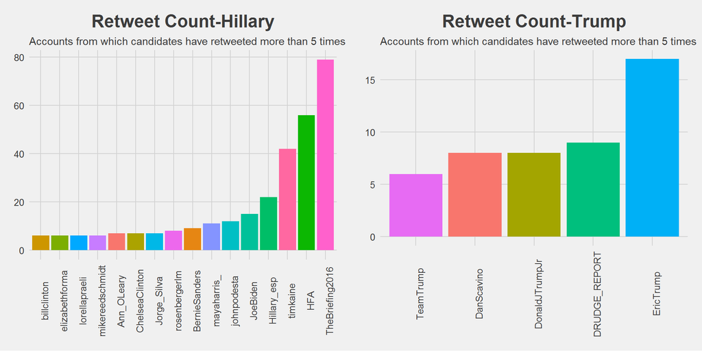

```r
temp=tweets %>% select(handle,is_retweet,original_author) %>% filter(is_retweet=="True")  %>% group_by(handle,original_author) %>% tally()
temp=temp[temp$n>5,]
plot1=ggplot(temp[temp$handle=="HillaryClinton",],aes(reorder(original_author,n),n,fill=original_author))+geom_bar(stat="identity")+theme_fivethirtyeight()+theme(legend.position = "none",axis.text.x=element_text(angle=90),plot.title=element_text(hjust=0.5))+labs(x="",y="Count",title="Retweet Count-Hillary",subtitle="Accounts from which candidates have retweeted more than 5 times")

plot2=ggplot(temp[temp$handle=="realDonaldTrump",],aes(reorder(original_author,n),n,fill=original_author))+geom_bar(stat="identity")+theme_fivethirtyeight()+theme(legend.position = "none",axis.text.x=element_text(angle=90),plot.title=element_text(hjust=0.5))+labs(x="",y="Count",title="Retweet Count-Trump",subtitle="Accounts from which candidates have retweeted more than 5 times")
plot_grid(plot1,plot2,align="v")
```

```r
theme_set(theme_cowplot(font_size=12))
```

# Using RSentiment package:

We use the RSentiment package to know about the sentiment of the tweets.

## Hillary Tweets

```r
Hillary=subset(tweets,handle=="HillaryClinton")
Hillary=Hillary %>% filter(!(is_retweet=="True"))
Trump=subset(tweets,handle=="realDonaldTrump")
Trump=Trump %>% filter(!(is_retweet=="True"))
clean=function(x){
  x$text=str_replace_all(x$text,'[^[:alnum:]]',' ')
  x$text=gsub("[[:digit:]]"," ",x$text)
  x$text=gsub("[\t]{2,}"," ",x$text)
  x$text=gsub("https.*"," ",x$text)
  return(x)
}
head(Hillary$text)
```

```
## [1] "The question in this election: Who can put the plans into action that will make your life better? https://t.co/XreEY9OicG"
## [2] "If we stand together, there's nothing we can't do. \n\nMake sure you're ready to vote: https://t.co/tTgeqxNqYm https://t.co/Q3Ymbb7UNy"
## [3] "Both candidates were asked about how they'd confront racial injustice. Only one had a real answer. https://t.co/sjnEokckis"
## [4] "This election is too important to sit out. Go to https://t.co/tTgeqxNqYm and make sure you're registered. #NationalVoterRegistrationDay -H"
## [5] "When Donald Trump goes low...register to vote: https://t.co/tTgeqxNqYm https://t.co/DXz9dEwsZS"
## [6] "Donald Trump lied to the American people at least 58 times during the first presidential debate. (We counted.) https://t.co/h43O6Rws4S"
```

```r
Hillary=as.data.frame(clean(Hillary))
Trump=as.data.frame(clean(Trump))
corpus=Corpus(VectorSource(list(Hillary$text)))
corpus = tm_map(corpus, removePunctuation)
corpus = tm_map(corpus, content_transformer(tolower))
corpus = tm_map(corpus, removeNumbers)
corpus = tm_map(corpus, stripWhitespace)
corpus = tm_map(corpus, removeWords, stopwords('english'))
dtm_Hillary = DocumentTermMatrix(VCorpus(VectorSource(corpus[[1]]$content)))
freq_Hillary <- colSums(as.matrix(dtm_Hillary))
```

We are using Rsentiment package which classifies the words into 6 categories:Positive,Negative,Neutral,Very Positive,Very Negative,Sarcastic .

```r
sentiments_Hillary = calculate_sentiment(names(freq_Hillary))
sentiments_Hillary = cbind(sentiments_Hillary, as.data.frame(freq_Hillary))
```

## Calculating & Visualising Sentiments:

```r
positive=sentiments_Hillary[sentiments_Hillary$sentiment=="Positive",]
positive=positive %>% arrange(desc(freq_Hillary))
negative=sentiments_Hillary[sentiments_Hillary$sentiment=="Negative",]
negative=negative %>% arrange(desc(freq_Hillary))
neutral=sentiments_Hillary[sentiments_Hillary$sentiment=="Neutral",]
neutral=neutral %>% arrange(desc(freq_Hillary))
```

## Positive Tweets

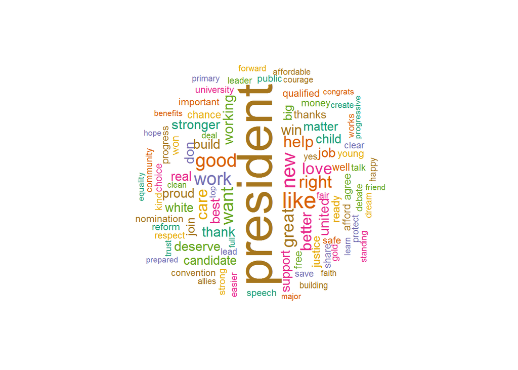

```r
wordcloud(positive$text,positive$freq_Hillary,scale=c(4,.5),min.freq=10,max.words = 100,random.order=FALSE,random.color=TRUE,rot.per=0.4,colors=brewer.pal(7,"Dark2"))
```

## Negative Tweets

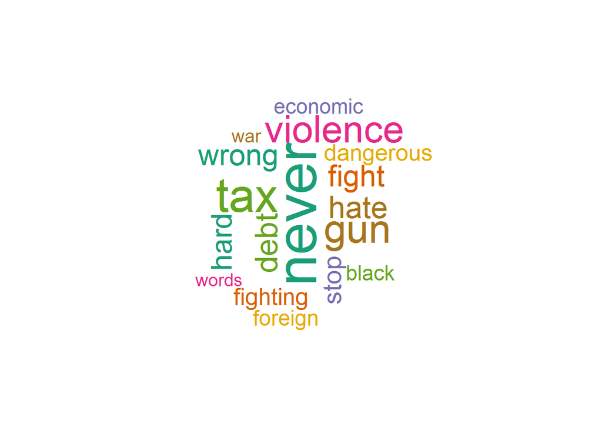

```r
wordcloud(negative$text,negative$freq_Hillary,scale=c(4,.1),random.order=FALSE,random.color=TRUE,min.freq=20,colors=brewer.pal(7,"Dark2"))
```

## Neutral Tweets

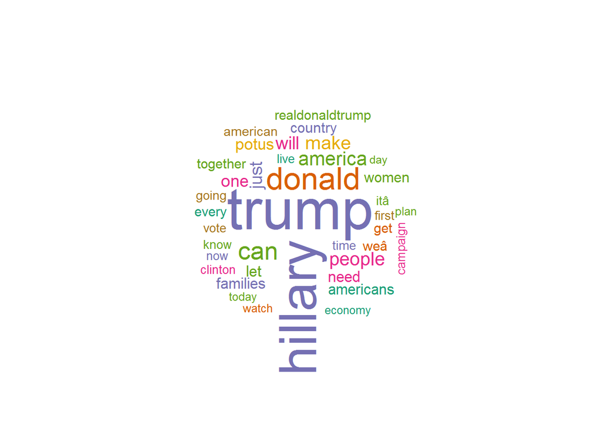

```r
wordcloud(neutral$text,neutral$freq_Hillary,scale=c(4,.5),min.freq=60,random.order=FALSE,random.color=TRUE,colors=brewer.pal(7,"Dark2"))
```

# Trump Tweets

Similarly we repeat the steps for Trump tweets and build a wordcloud.

```r
head(Trump$text)
```

```
## [1] "Join me for a  pm rally   tomorrow at the Mid America Center in Council Bluffs  Iowa  Tickets â    "
## [2] "Once again  we will have a government of  by and for the people  Join the MOVEMENT today   "
## [3] "Hillary Clinton s Campaign Continues To Make False Claims About Foundation Disclosure    "
## [4] " CNBC  Time magazine online polls say Donald Trump won the first presidential debate  via  WashTimes   MAGA  "
## [5] "Great afternoon in Little Havana with Hispanic community leaders  Thank you for your support   ImWithYou  "
## [6] "In the last    hrs  we have raised over    M from online donations and National Call Day  and weâ  re still going  Thank you America   MAGA"
```

```r
corpus=Corpus(VectorSource(list(Trump$text)))
corpus = tm_map(corpus, removePunctuation)
corpus = tm_map(corpus, content_transformer(tolower))
corpus = tm_map(corpus, removeNumbers)
corpus = tm_map(corpus, stripWhitespace)
corpus = tm_map(corpus, removeWords, stopwords('english'))
dtm_Trump = DocumentTermMatrix(VCorpus(VectorSource(corpus[[1]]$content)))
freq_Trump <- colSums(as.matrix(dtm_Trump))
```

```r
sentiments_Trump = calculate_sentiment(names(freq_Trump))
sentiments_Trump = cbind(sentiments_Trump, as.data.frame(freq_Trump))
```

## Calculating & Visualising Sentiments:

```r
positive=sentiments_Trump[sentiments_Trump$sentiment=="Positive",]
positive=positive %>% arrange(desc(freq_Trump))
negative=sentiments_Trump[sentiments_Trump$sentiment=="Negative",]
negative=negative %>% arrange(desc(freq_Trump))
neutral=sentiments_Trump[sentiments_Trump$sentiment=="Neutral",]
neutral=neutral %>% arrange(desc(freq_Trump))
```

## Positive Tweets

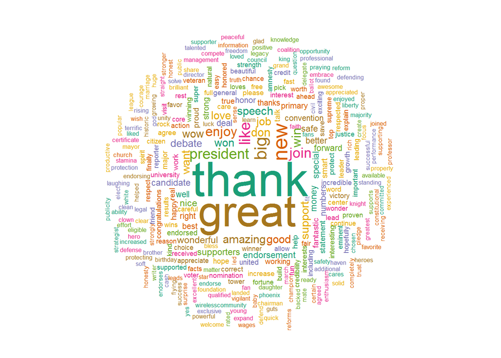

```r
wordcloud(positive$text,positive$freq_Trump,random.order=FALSE,random.color=TRUE,rot.per=0.4,colors=brewer.pal(7,"Dark2"))
```

## Negative Tweets

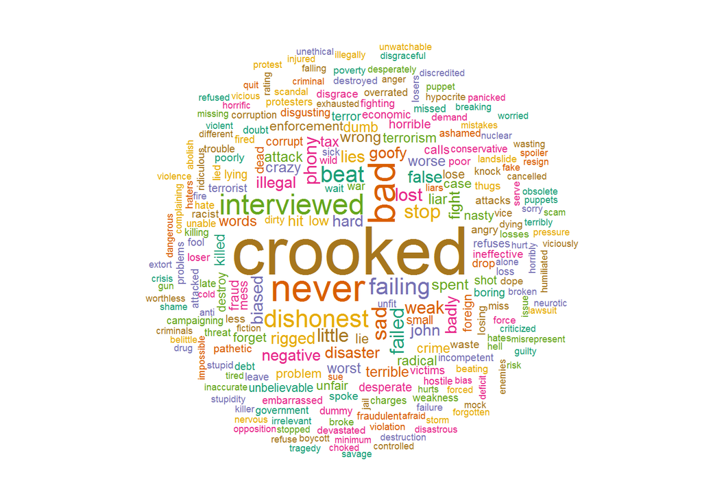

```r
wordcloud(negative$text,negative$freq_Trump,random.order=FALSE,random.color=TRUE,colors=brewer.pal(7,"Dark2"))
```

## Neutral Tweets

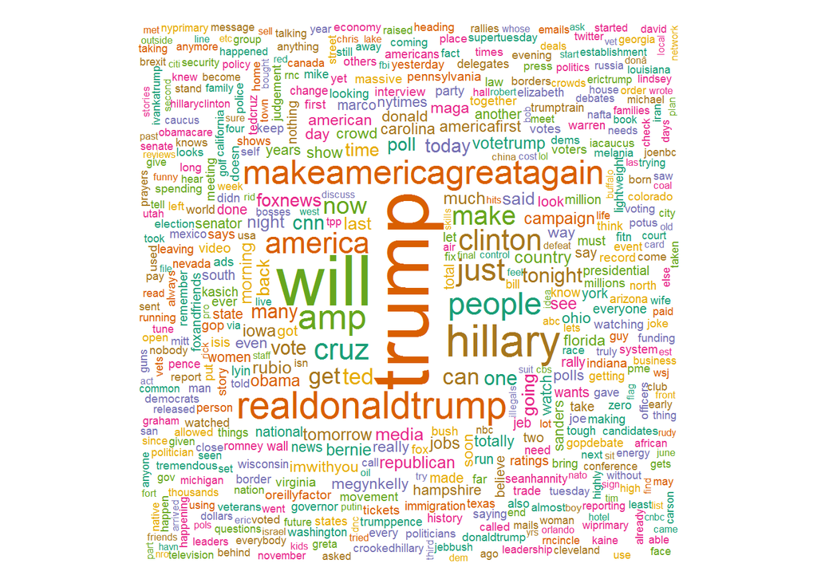

```r
wordcloud(neutral$text,neutral$freq_Trump,random.order=FALSE,random.color=TRUE,colors=brewer.pal(7,"Dark2"))
```

# TF-IDF:

We wish to know the most important words used in the tweet.For this we use * Term Frequency -Inverse Document Frequency matrix* .TF-IDF computes a weight which represents the importance of a term inside a document.It does this by comparing the frequency of usage inside an individual document as opposed to the entire data set (a collection of documents).

The importance increases proportionally to the number of times a word appears in the individual document itself–this is called Term Frequency. However, if multiple documents contain the same word many times then you run into a problem. That’s why TF-IDF also offsets this value by the frequency of the term in the entire document set, a value called Inverse Document Frequency.

```r
temp=subset(tweets,!(is.na(tweets$text)))
temp=as.data.frame(clean(temp))
temp=temp %>% unnest_tokens(word,text) %>% count(handle,word,sort=TRUE) %>% ungroup()
total_words=temp %>% group_by(handle) %>% summarise(count=n())
temp=left_join(temp,total_words)
kable(head(temp,20),"html") %>% kable_styling(bootstrap_options="condensed",position="center")
```

| handle | word | n | count |
| --- | --- | --- | --- |
| HillaryClinton | the | 1805 | 6166 |
| realDonaldTrump | the | 1785 | 5816 |
| HillaryClinton | to | 1748 | 6166 |
| HillaryClinton | â | 1429 | 6166 |
| HillaryClinton | s | 1263 | 6166 |
| HillaryClinton | a | 1131 | 6166 |
| realDonaldTrump | to | 1089 | 5816 |
| HillaryClinton | and | 1002 | 6166 |
| realDonaldTrump | a | 944 | 5816 |
| realDonaldTrump | and | 922 | 5816 |
| realDonaldTrump | in | 890 | 5816 |
| realDonaldTrump | i | 883 | 5816 |
| HillaryClinton | trump | 881 | 6166 |
| HillaryClinton | of | 873 | 6166 |
| HillaryClinton | in | 838 | 6166 |
| realDonaldTrump | you | 800 | 5816 |
| realDonaldTrump | is | 779 | 5816 |
| HillaryClinton | we | 762 | 6166 |
| HillaryClinton | hillary | 743 | 6166 |
| realDonaldTrump | trump | 743 | 5816 |

Here *n* is the number of times the word is used in the book and count is the total number of terms in the tweet of the respective handle.We look at the distribution of n/total for each handle.This is exactly what term frequency is.

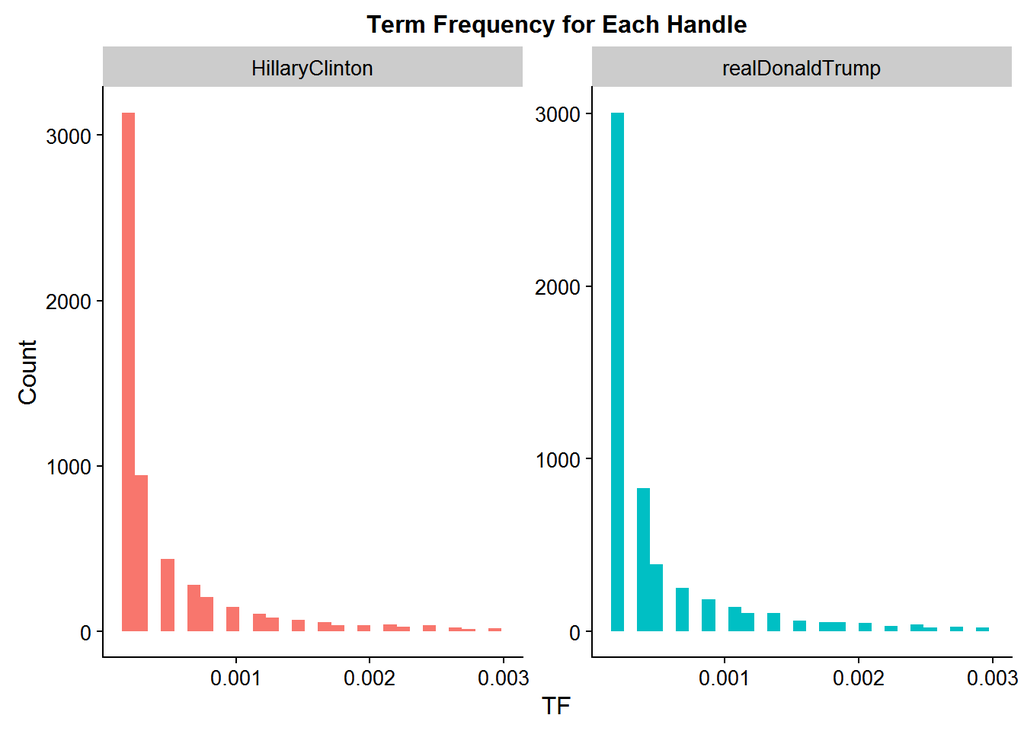

```r
ggplot(temp,aes(n/count,fill=handle))+geom_histogram(show.legend = FALSE)+facet_wrap(~handle,scales="free")+xlim(NA,0.0030)+labs(x="TF",y="Count",title="Term Frequency for Each Handle")
```

## Using the bind_tf_idf function:

We calculated the TF manually above .Lets now do it with the help of the function *bind_tf_idf* from *tidytext* package.This requires word,handle,count as input.

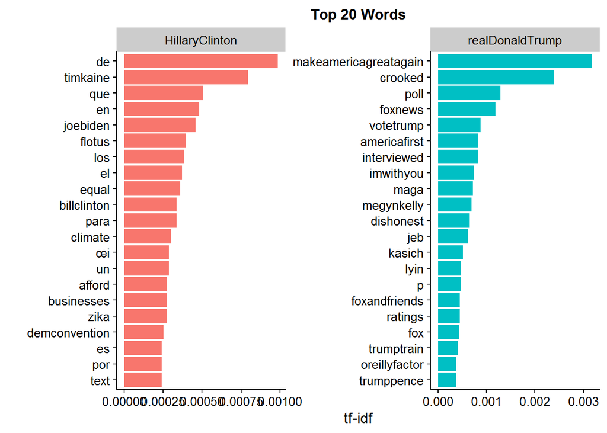

```r
temp=temp %>% filter(!(is.na(handle))) %>% bind_tf_idf(word,handle,n)
temp1=temp %>% select(-count) %>% arrange(desc(tf_idf)) %>% mutate(word=factor(word,levels=rev(unique(word))))
temp1 %>% group_by(handle) %>% top_n(20) %>% ungroup() %>% ggplot(aes(word,tf_idf,fill=handle))+geom_col(show.legend=FALSE)+labs(x="",y="tf-idf",title="Top 20 Words")+facet_wrap(~handle,ncol=2,scales="free")+coord_flip()
```

## Wordcloud of Most Important Words:

We plot *top 100* most important words for each handle.This is done by tf-idf.

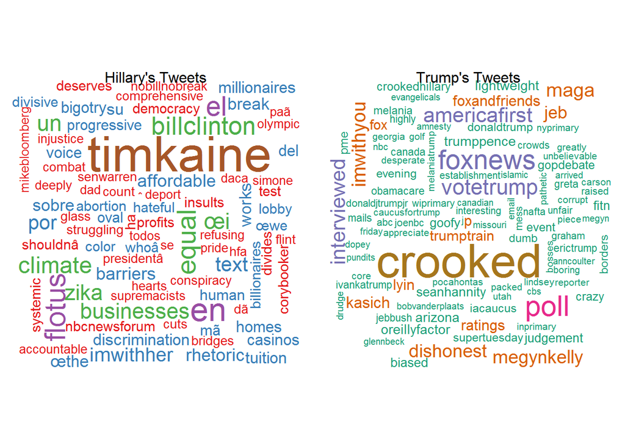

```r
par(mfrow=c(1,2))
temp1 %>% filter(handle=="HillaryClinton") %>% with(wordcloud(word,tf_idf,max.words=100,colors=brewer.pal(8,"Set1")))
text(x=0.5,y=1,"Hillary's Tweets")
temp1 %>% filter(handle=="realDonaldTrump") %>% with(wordcloud(word,tf_idf,max.words=100,colors=brewer.pal(8,"Dark2")))
text(x=0.5,y=1,"Trump's Tweets")
```

```r
par(mfrow=c(1,1))
```

# Relationship between Words:

## Bigrams

A *bigram* is a collection of two words.We examine the most used bigrams in the tweets.

```r
temp=clean(tweets)
temp=temp %>% select(handle,text) %>% unnest_tokens(bigram,text,token="ngrams",n=2)
kable(head(temp,10),"html") %>% kable_styling(bootstrap_options="condensed",position="center")
```

| handle | bigram |
| --- | --- |
| HillaryClinton | the question |
| HillaryClinton | question in |
| HillaryClinton | in this |
| HillaryClinton | this election |
| HillaryClinton | election who |
| HillaryClinton | who can |
| HillaryClinton | can put |
| HillaryClinton | put the |
| HillaryClinton | the plans |
| HillaryClinton | plans into |

A lot of the bigrams are uninteresting words like the,of,will etc..we remove these words and analyse.

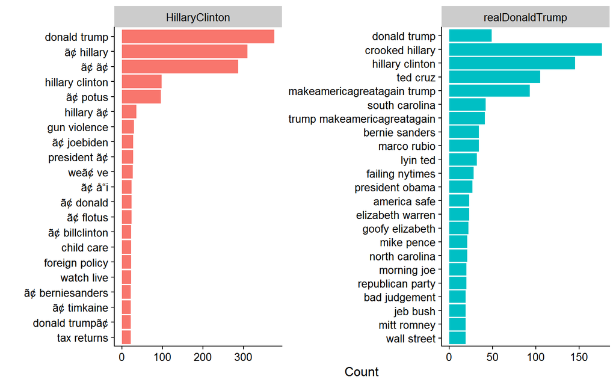

```r
tempseperated=temp %>% separate(bigram,c("word1","word2"),sep=" ")
tempfiltered=tempseperated %>% filter(!(word1 %in% stop_words$word)) %>% filter(!(word2 %in% stop_words$word))
temp=tempfiltered %>% unite(bigramwords,word1,word2,sep=" ") %>% group_by(bigramwords,handle) %>% tally()%>% ungroup() %>% arrange(desc(n))  %>% mutate(bigramwords=factor(bigramwords,levels=rev(unique(bigramwords))))
temp %>% group_by(handle)  %>% top_n(20) %>% ggplot(aes(bigramwords,n,fill=handle))+geom_col(show.legend=FALSE)+labs(x="",y="Count")+facet_wrap(~handle,ncol=2,scales="free")+coord_flip()
```

## Using TF-IDF to know Most Important Bigrams:

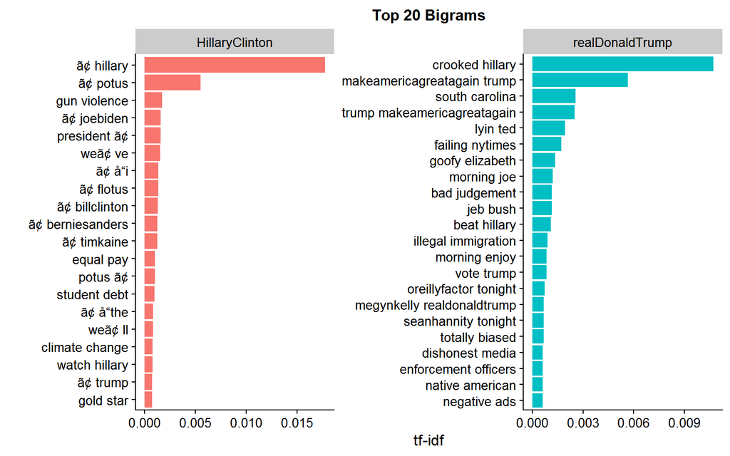

```r
temp =temp %>% bind_tf_idf(bigramwords,handle,n)
temp1=temp %>% select(-n) %>% arrange(desc(tf_idf)) %>% mutate(bigramwords=factor(bigramwords,levels=rev(unique(bigramwords))))
temp1 %>% group_by(handle) %>% top_n(20) %>% ungroup() %>% ggplot(aes(bigramwords,tf_idf,fill=handle))+geom_col(show.legend=FALSE)+labs(x="",y="tf-idf",title="Top 20 Bigrams")+facet_wrap(~handle,ncol=2,scales="free")+coord_flip()
```

# Hashtag Analysis:

We extract hashtags from the tweets and analyse which hashtag has been repeatedly used by the candidates.

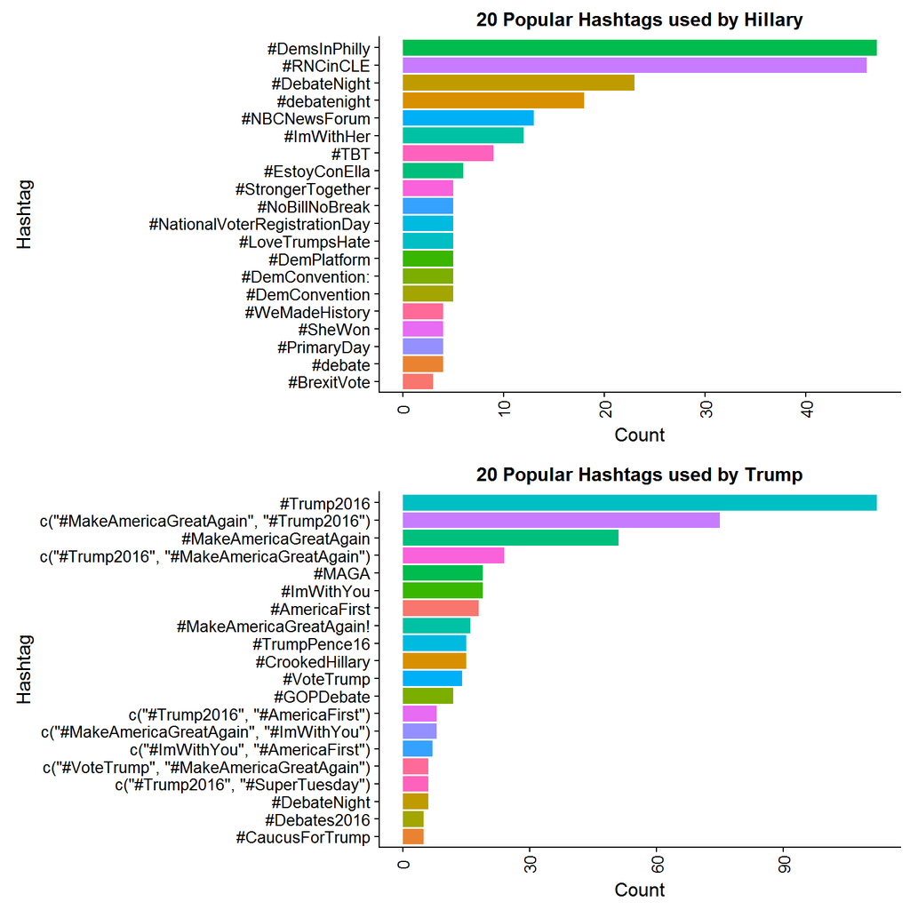

```r
temp=tweets %>% select(handle,text)
temp$hashtag=as.character(str_extract_all(temp$text,"#\\S+"))
temp$hashtag=ifelse(temp$hashtag=='character(0)',NA,temp$hashtag)
temp=temp %>% group_by(handle,hashtag)  %>% drop_na(hashtag) %>% tally()
hashhil=temp %>% filter(handle=="HillaryClinton") %>% arrange(desc(n))
hashtrum=temp %>% filter(handle=="realDonaldTrump") %>% arrange(desc(n))
p1=ggplot(head(hashhil,20),aes(reorder(hashtag,n),n,fill=hashtag))+geom_bar(stat="identity")+theme(legend.position="none",axis.text.x=element_text(angle=90,vjust=0.5),plot.title=element_text(hjust=0.5))+labs(x="Hashtag",y="Count",title="20 Popular Hashtags used by Hillary")+coord_flip()
p2=ggplot(head(hashtrum,20),aes(reorder(hashtag,n),n,fill=hashtag))+geom_bar(stat="identity")+theme(legend.position="none",axis.text.x=element_text(angle=90,vjust=0.5),plot.title=element_text(hjust=0.5))+labs(x="Hashtag",y="Count",title="20 Popular Hashtags used by Trump")+coord_flip()
plot_grid(p1,p2,ncol=1,align="v")
```

# Conclusion:

- This project makes use of the *tidytext package* to uncover most interesting trends of the tweets by US Presidential Candidates.
- Various concepts like TF-IDF,bigram,wordcloud have been used judiciously thereby understanding the power and use of these in text analytics.
- There was a scope for analysing the trends of the tweets by month,time with bigram or most used words in the day which is unexplored in this kernel.This will be taken up in future analysis.

**Thanks for reading**